# 東京都 (議員定数：25 → 30)

アルゴリズムによる衆議院小選挙区の区割り改定案

ALARM Japan プロジェクトチーム  
July 3, 2022

**東京都**

人口： 13,564,222 人（2020年）

|  | 現行 | 新たな区割り | アルゴリズムの提案 |
| --- | --- | --- | --- |
| **1票の格差** |  |  |  |
| 県内較差 | 1.190 | 1.433 | 1.178 |
| 改善率 | - | −127.9% | 6.3% |
| **選挙区の状況** |  |  |  |
| 選挙区数 | 25 | 30 | 30 |
| 市区町村の分割 | 17<sup>a</sup> | 8<sup>b</sup> | 15<sup>c</sup> |
| 郡の分割 | 0 | 0 | 0 |
| 広域連携地域の分割 | 0 | 0 | 0 |

<sup>a</sup> 港区、新宿区、台東区、品川区、目黒区、大田区、世田谷区、中野区、杉並区、 豊島区、板橋区、練馬区、足立区、江戸川区、八王子市、多摩市、稲城市  
<sup>b</sup> 大田区、世田谷区、杉並区、板橋区、練馬区、足立区、江戸川区、八王子市  
<sup>c</sup> 港区、新宿区、品川区、目黒区、大田区、世田谷区、中野区、杉並区、 豊島区、板橋区、練馬区、足立区、江戸川区、八王子市、多摩市

# 現行の区割り(２３区地域、島嶼部を含む)

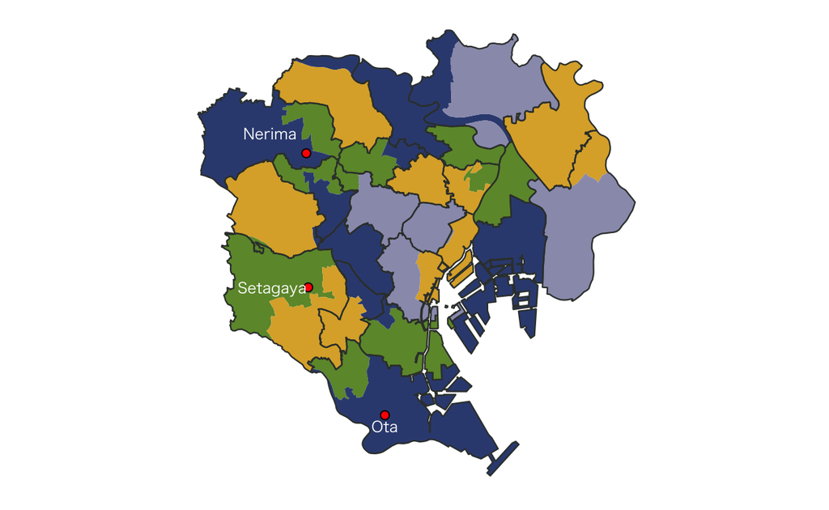

島嶼部は、品川区の一部、大田区の一部と同じ東京３区

# 現行の区割り(多摩地域)

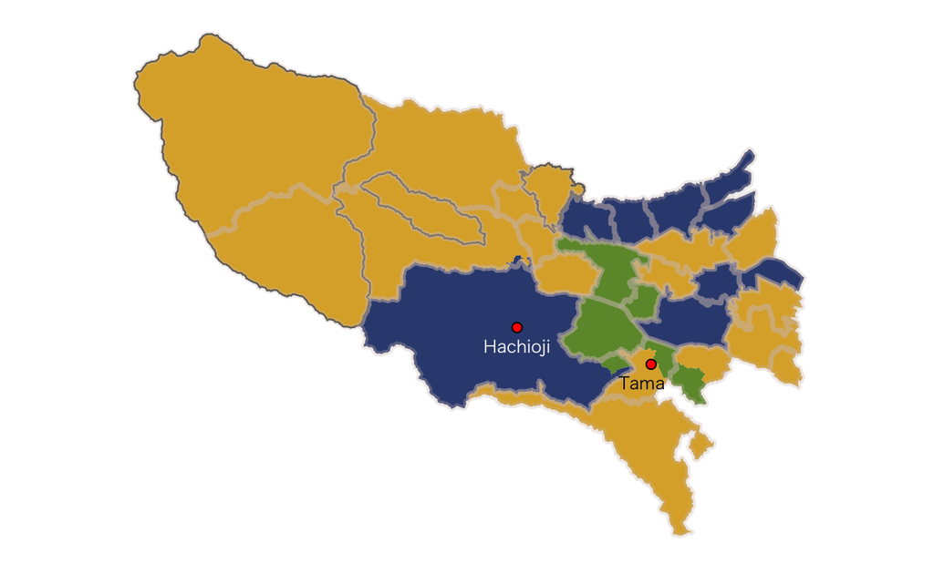

# アルゴリズムの提案

アルゴリズムが提案した5,000案のうち、一票の格差が最小のもの

### 23区地域(島嶼部を含む)

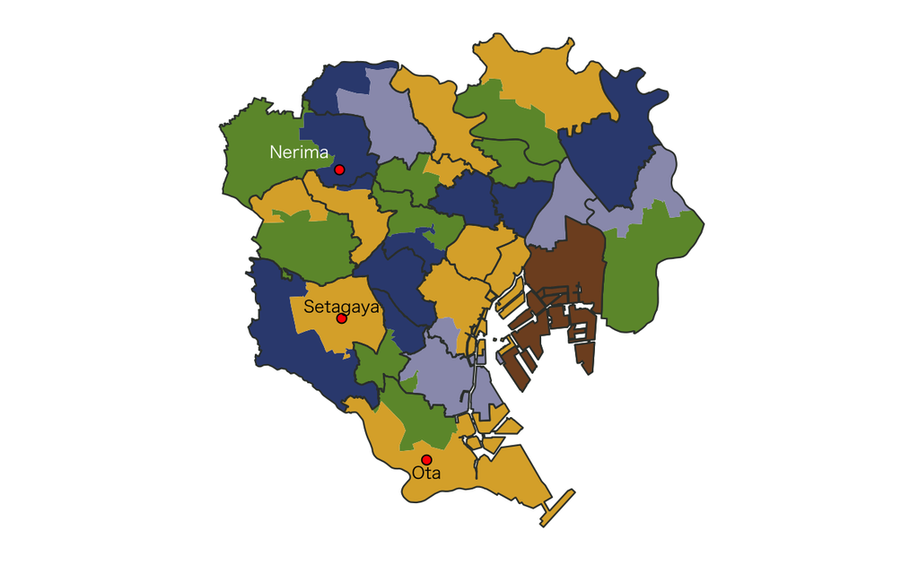

島嶼部は、航路で結ばれている港区海岸と同一の選挙区

### 多摩地域

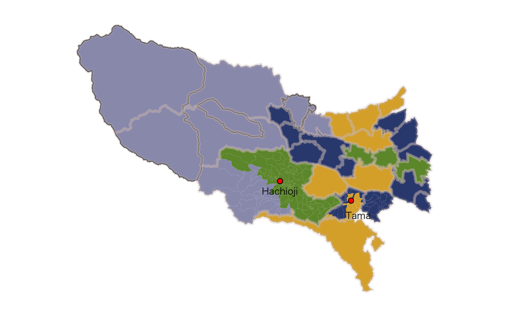

# 共起分析

### 23区地域

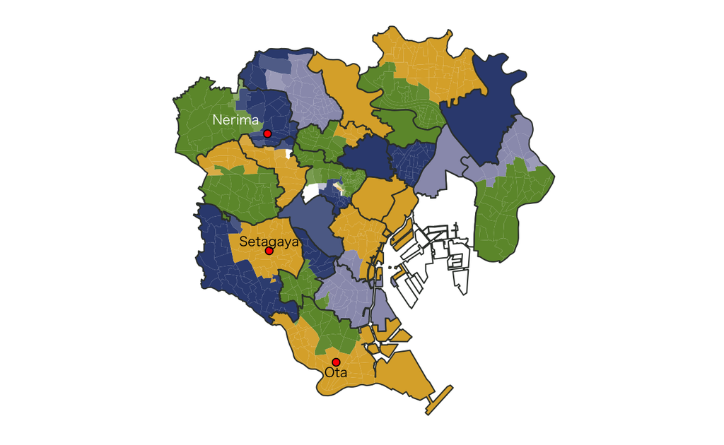

### 多摩地域

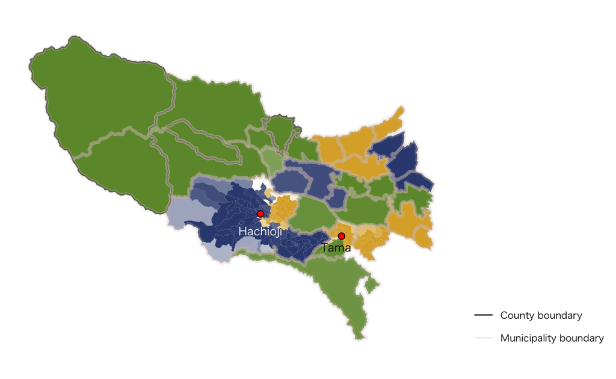

# アルゴリズム設定

- 各選挙区の人口 :
  - 23区地域: (日本人人口 / 選挙区数:21) ± 6%
  - 多摩地域: (日本人人口 / 選挙区数:9) ± 8%
- 市区町村を基本の単位として扱う
  - ただし、現状の区割りにおいて分割されている市区町村については、シミュレーションにおいても分割を許容し、国勢調査における小地域を基本の単位として扱う
  - 現状の区割りにおいて分割されている市区町村は、港区、新宿区、台東区、品川区、目黒区、大田区、世田谷区、中野区、杉並区、 豊島区、板橋区、練馬区、足立区、江戸川区、八王子市、多摩市、稲城市
- 市区町村の分割数の制限 (`add_constr_splits`)と、市区町村の複数選挙区への分割の制限(`add_constr_multisplits`) をそれぞれを設定
- 郡の分割は、現行の区割りにて分割されている場合のみ許容
- 離島は、航路で結ばれている本土の市区町村と同一の選挙区にする
  - 東京都の島嶼部は、航路で結ばれている港区海岸と同一の選挙区とした
- 逐次モンテカルロ法(SMC)による4つの独立したシミュレーションにより、23区地域では40,000、多摩地域では240,000区割り改定案を作成。
- 以下の案を棄却し有効な案を選定
  - 市区町村が3つ以上の選挙区に分割される案
  - 現状の区割りにおいて分割されていない郡・市区町村が分割される案
- 有効な案の中から5,000の案を無作為に抽出

### 東京都特有の設定

- [「区割り改定案の作成方針」](https://www.soumu.go.jp/main_content/000794997.pdf)では、「区部及び多摩地域の区域を尊重するものとする」とされている。よって、23区地域と多摩地域に対し、別々に区割りシミュレーションを行うことにより、23区地域と多摩地域にまたがる選挙区が作成されないようにした。
- その際、東京の小選挙区数30を、23区地域と多摩地域それぞれの日本人人口に基づき比例配分し、以下の通り定数を割り当てた。
  - 23区地域: 21
  - 多摩地域: 9
- 江東区の人口は、選挙区1区あたりの人口（23区の総人口 / 選挙区数）より大きい。そのため、23区地域の区割りシミュレーションでは、江東区を対象外とし、単独で選挙区を構成させた。
- 以下の臨海部の地域は、橋や道路により結ばれているため、隣接するものとして扱った。
  - 大田区東海と大田区平和島
  - 大田区東海と大田区京浜島
  - 大田区昭和島と大田区大森東
  - 品川区八潮と品川区東八潮
  - 品川区八潮と品川区東大井
  - 品川区八潮と品川区東品川5丁目
  - 品川区東品川1・3・4丁目と品川区東品川2丁目
  - 品川区東品川2丁目と品川区東品川5丁目
  - 港区海岸と港区台場
  - 中央区佃・月島・勝鬨と中央区の大部分の地域
  - 中央区浜離宮庭園の各地域

# データとプログラム

- [**Dataverse** : シュミレーションデータ](https://doi.org/10.7910/DVN/Z9UKSH)
- [**GitHub** : プログラム・コード](https://github.com/alarm-redist/japan)